# Splicing report

This report measures intronic RNA during *Dictyostelium discoideum* development and asks what it suggests about splicing. It compares total single-cell RNA (snapTotal-seq), poly(A) single-cell RNA (10x) and rRNA-depleted bulk RNA from AX4.

**Working revision, 5 November 2026.** We updated the counting explanation, the replicate results and the sensitivity analyses. The main pooled figures and tables use the original counts from both strands. Section 5 gives sense-read results for poly(A) and bulk. snapTotal does not preserve strand, so we checked it only by excluding the 96 genes that overlap antisense loci. This version is not final.

At 0 h and 16 h, intronic evidence makes up **0.59%–1.33%** of accepted counts in the shared gene set. Detected introns are **1.07–1.24 times as long** as expression-matched undetected introns in 13 estimates from individual plates, replicates and libraries. The intronic fraction is higher at 16 h in all three methods, and the poly(A) increase remains after the checks in section 5. None of these measurements is a direct measure of splicing rate.

**Convention.** Unless stated otherwise, comparisons that include poly(A) use five subsets of poly(A) cells, each with the same exon depth as snapTotal (section 2). We report the median and range of the five subsets. Section 8 collects the key numbers.

## 1. Data and counting

We recounted all three methods from their alignments with one set of rules, on 7,785 intron-containing protein-coding genes on chromosomes 1–6. The annotation has one transcript model per gene, but one model per gene does not mean that the genes lack alternative splicing. We selected genes labelled `protein_coding`, which unintentionally left out 1,945 RefSeq models labelled `mRNA`. Of these, 743 meet the other criteria. We did not add them when we found the omission, because they were not selected for RNA support and many lack spliced reads. They still compete for reads, so reads overlapping them are ambiguous.

| Method | Cells or libraries at 0 h / 16 h | Time points |
| --- | --- | --- |
| Total scRNA ([snapTotal-seq](https://www.nature.com/articles/s41467-024-50291-3)) | 149 / 164 cells after QC, two plates per time point | 0, 16 h |
| Poly(A) scRNA (10x, AX4 atlas) | 6,626 / 11,827 atlas cells, three replicates | 0–20 h, every 4 h |
| Bulk total RNA ([Rosengarten et al.](https://academic.oup.com/g3journal/article/7/2/387/6027566), GSE90829) | 2 / 1 libraries | 0–24 h, every 2 h |

A **unit** is all the reads from one molecule for one gene. In single-cell data, these reads share a cell barcode, gene and unique molecular identifier (UMI). In bulk data, a unit is one paired fragment.

We count reads from both strands in all methods, because snapTotal does not preserve strand. A unit is **ambiguous** and excluded if any aligned base overlaps a second annotated gene, including its introns and on either strand. Splice gaps and the unsequenced gap between paired reads do not count as overlap. Parts of a gene that do not overlap another gene can still contribute.

A **conflict** is when reads in the same unit disagree about one intron: one read contains sequence inside the intron and another read skips it. The skip need not match both annotated intron ends, so an alternative splice site can also cause a conflict. A conflict therefore does not prove a technical error. We exclude conflicting units from the intronic fraction. Splicing of a different intron is not a conflict.

The **intronic fraction** is I / (I + E), where I is the number of units with any intronic base and E is the number of exon-only units. It measures the sequencing evidence we observe, not the fraction of complete transcripts retaining an intron. An exon-only unit can still come from a transcript that retains an intron elsewhere. Similar gene-level fractions are also used in RNA velocity research, although the counting rules vary ([Soneson et al., 2021](https://pmc.ncbi.nlm.nih.gov/articles/PMC7822509/)).

**Counting and replicate details**

Alignments come from STAR, run directly for snapTotal and bulk and through Cell Ranger 7.2.0 for poly(A). We count only primary, uniquely mapped reads. The aligner can report a read at more than one position, and "primary" is the main reported position. NH is the number of positions reported for a read, and it must equal 1. MAPQ is a mapping quality score, and STAR gives 255 to uniquely mapped reads. snapTotal uses valid 5-base UMIs from read 2. Poly(A) uses the cell barcode and UMI tags from Cell Ranger (CB and UB). In bulk data, both reads of a pair are assessed together. Each accepted unit is counted once. A unit with intronic sequence is intronic even if it also contains exon sequence, or shows that a different intron was removed. The retained gene models are identical in the two single-cell references. The poly(A) reference also contains the act15GFP, mCerulean and mCherry reporters.

The act15GFP, mCerulean and mCherry reporters identify three replicates within each multiplexed library. That the same reporter is the same replicate across time rests on the experimenter's records. Replicate analyses use the published reporter labels. Cells without one of the three labels are used only in pooled results. Cells are not independent biological replicates. The bulk comparison at 0 and 16 h uses the retained libraries, and section 7 has the full bulk time course.

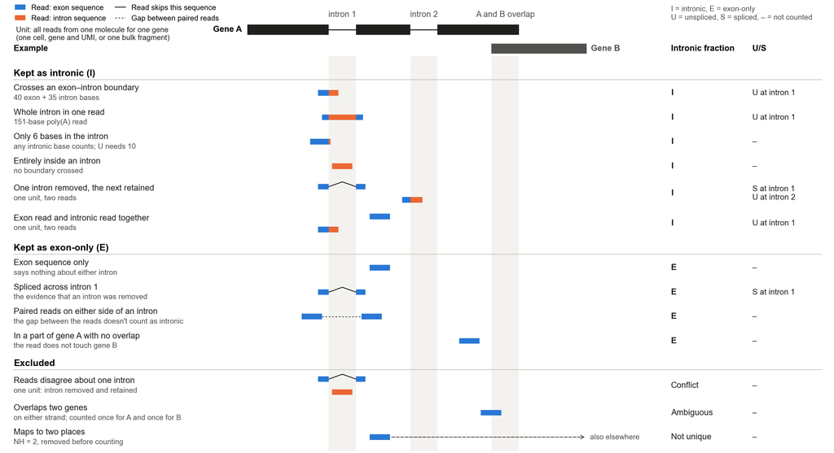

How example reads are counted. We passed each example through the counting code on a toy gene with 100-base introns. Reads are 75 bases unless stated. A unit is all the reads from one molecule for one gene: one cell, gene and UMI, or one paired fragment in bulk. I and E give the intronic fraction I / (I + E). U and S are counted separately for each intron. A read overlapping two genes is rejected for each gene, so it appears twice in the exclusion table.

## 2. Intronic abundance and gene detection

**Intronic evidence is at most 1.33% of counts in every method and is higher at 16 h in all three, but many genes have some:** 40%–97% of expressed genes have at least one intronic count.

**Depth matching.** Poly(A) has far more cells and counts than snapTotal, and deeper data detect more introns. We therefore drew five random orders of poly(A) cells at each time point, stopped each one at snapTotal's total exon UMIs, and recalculated all counts and matching in each subset. The subsets match exon depth, not capture chemistry. Bars use all cells, and open circles show the five subsets.

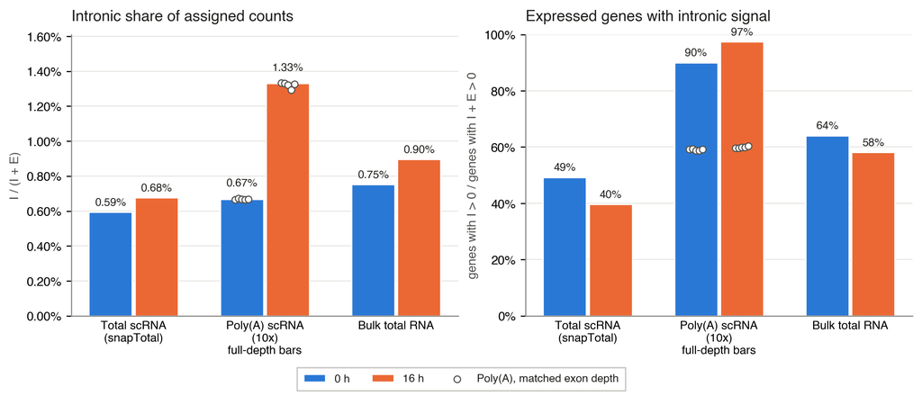

Left: intronic share I / (I + E). Right: share of expressed genes with at least one intronic count. Expressed: at least one accepted count after pooling all retained cells or libraries. Bars use all cells or libraries; open circles are the five depth-matched poly(A) subsets.

**"Expressed" means at least one count after pooling.** Poly(A) detects 7,741 and 7,778 of the 7,785 genes at 0 and 16 h, but only 5,454 and 5,319 have exon counts in at least 10% of cells, 2,065 and 1,620 in at least half of cells, and half of all counts come from 69 and 310 genes. Detection after pooling thousands of cells does not mean that most genes are appreciably expressed in each cell.

| Method | Intronic fraction, 0 h / 16 h | Genes with intronic signal, 0 h / 16 h |
| --- | --- | --- |
| Total scRNA (snapTotal) | 0.593% / 0.676% | 3,425/6,958 (49%) / 2,865/7,232 (40%) |
| Poly(A) scRNA, all cells | 0.668% / 1.330% | 6,969/7,741 (90%) / 7,576/7,778 (97%) |
| Bulk total RNA | 0.752% / 0.896% | 4,665/7,287 (64%) / 4,372/7,522 (58%) |

| Hour | Poly(A) subset cells | Poly(A) intronic fraction at matched depth | Poly(A) expressed genes with intronic signal at matched depth |
| --- | --- | --- | --- |
| 0 | 554–598 | 0.664%–0.671% | 58.7%–59.3% |
| 16 | 347–362 | 1.294%–1.333% | 59.6%–60.4% |

Depth barely changes the poly(A) intronic fraction, but it strongly changes gene detection. With all cells, poly(A) finds intronic signal in 90% and 97% of expressed genes. At snapTotal's exon depth this falls to 58.7%–59.3% and 59.6%–60.4%, compared with snapTotal's 49.2% and 39.6%.

Although snapTotal is designed to capture non-polyadenylated RNA, it does not have a higher intronic fraction than poly(A).

**Full-depth assigned and excluded counts**

All cells or libraries, full-depth poly(A). Exclusions are listed per unit and gene, so one ambiguous molecule can appear at several genes. A unit that is both ambiguous and conflicting is listed as ambiguous.

| Method | Hour | Exon-only units (E) | Intronic units (I) | Ambiguous gene (A) | Splice conflict (C) | C/(E+I+A+C) |
| --- | --- | --- | --- | --- | --- | --- |
| Total scRNA | 0 | 11,790,377 | 70,339 | 8,660 | 23,631 | 0.199% |
| Total scRNA | 16 | 3,340,238 | 22,739 | 1,724 | 4,215 | 0.125% |
| Poly(A) scRNA | 0 | 133,220,554 | 895,523 | 212,542 | 136,672 | 0.102% |
| Poly(A) scRNA | 16 | 111,875,547 | 1,508,195 | 314,146 | 292,193 | 0.256% |
| Bulk total RNA | 0 | 6,533,758 | 49,490 | 9,150 | 15,654 | 0.237% |
| Bulk total RNA | 16 | 3,178,575 | 28,747 | 5,087 | 8,438 | 0.262% |

Conflicts are 0.10%–0.26% of units after the earlier filters, not of all physical molecules. Among units with intronic or conflicting evidence, C/(I+C) is 13.2%–25.1%. We cannot assume that all conflicts are truly unspliced, so we tested two scenarios on pooled counts from both strands, without confidence intervals. Counting all conflicts as exon-only leaves the 0–16 h change within 0.005 percentage points of the reported value. Counting all conflicts as intronic changes it from 0.66 to 0.81 percentage points in poly(A), 0.14 to 0.17 in bulk and 0.08 to 0.01 in snapTotal. The poly(A) and bulk increases remain in both scenarios, but the small snapTotal increase depends on how conflicts are treated. Section 5 gives the sense-read results, which weaken the bulk increase. Ambiguity is classified first, so conflicts that also overlap a second gene are counted in A, not C.

## 3. Intron length

**Detected introns are longer than expression-matched controls in every method and hour, but only modestly: 1.08–1.17×.**

We tested whether introns with detectable unspliced evidence are longer than expression-matched introns without it. A longer intron is a bigger target for stray reads, so an intron counts as detected only from reads crossing an annotated exon–intron boundary with at least 10 bases on each side (the **anchors**). Each detected intron (**case**) needs at least 2 supporting units, from at least 2 cells in single-cell data. It is paired with an intron with no intronic reads (**control**) from a gene of similar expression. The paired ratio is 2^median log2(case length / control length), so 1.10 means about 10% longer. The boundary rule applies to the intron length comparison. Intronic abundance and gene span accept any intronic base, and U/S has its own rules (section 6).

**Matching details**

Boundary support requires one uninterrupted aligned block (no indels) with ≥10 exon and ≥10 intron bases. Targets need ≥20 intron bases and ≥10 bases in each adjacent exon. An intron with some evidence but too little to be a case (one supporting unit, say, or reads only inside the intron) is neither a case nor a control. It is left out of this comparison, but its counts still contribute to intronic abundance. Parent genes need ≥20 exon counts and, for single-cell data, exon detection in ≥5 cells.

Matching uses log2(exon counts + 1) and, for single-cell data, log2(exon-detected cells + 1), caliper 0.25 on each, one control per case, without replacement; length is not used. A ratio is reported only with ≥20 pairs and absolute standardized mean difference < 0.1 on each variable. Brackets are the 2.5–97.5% range over 500 resamples of parent genes with matching repeated. They reflect which genes were sampled, not biological replicates.

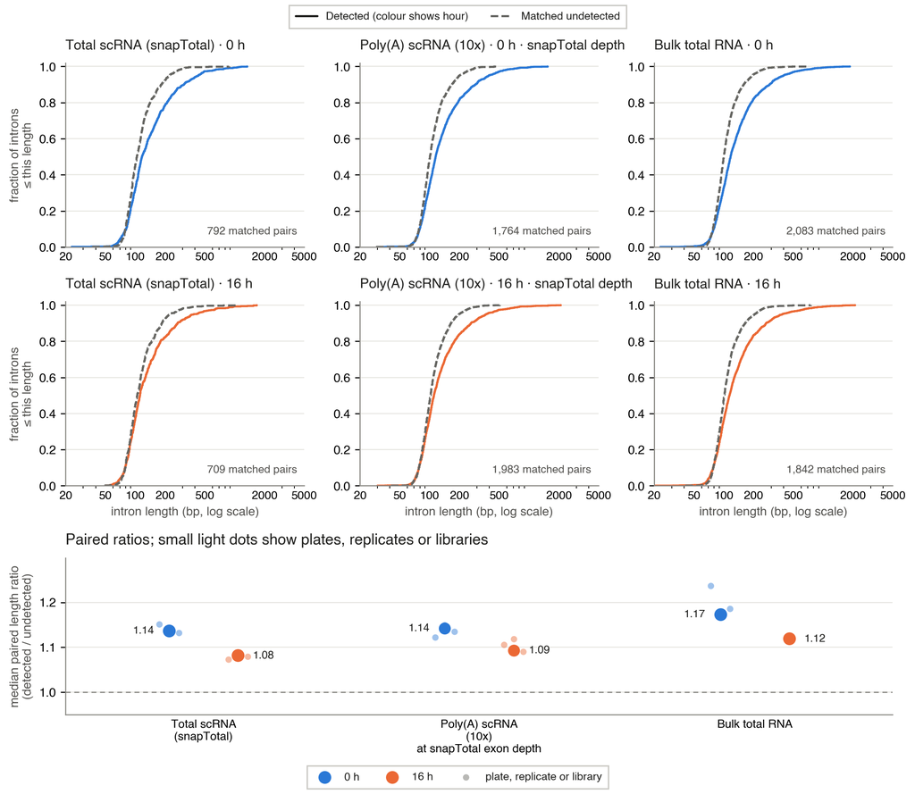

Upper panels: cumulative length distributions of detected introns (solid) and matched controls (dashed); log length axis. Bottom: paired ratio per method and hour; light dots are individual plates, replicates or libraries. Bulk 16 h has one retained library, so it has no separate replicate dots.

In every panel the solid curve lies slightly to the right of the dashed curve, mainly above about 100 bp. The difference is in the upper part of the length distribution, not a shift of the whole distribution.

| Method | Hour | Detected cases | Matched pairs | Cases matched | 10-bp ratio | 5-bp ratio | Relaxed-control ratio (pairs) |
| --- | --- | --- | --- | --- | --- | --- | --- |
| Total scRNA | 0 | 819 | 792 | 97% | 1.137 [1.08–1.18] | 1.129 [1.07–1.16] | 1.109 [1.05–1.15] (817) |
| Total scRNA | 16 | 714 | 709 | 99% | 1.082 [1.02–1.11] | 1.077 [1.03–1.11] | 1.047 [1.01–1.08] (712) |
| Poly(A) scRNA, snapTotal depth | 0 | 2,018–2,159 | 1,713–1,801 | 83%–85% | 1.142 (1.12–1.15) | 1.125 (1.11–1.15) | 1.104 (1.09–1.12) (1,856–1,988) |
| Poly(A) scRNA, snapTotal depth | 16 | 2,406–2,461 | 1,981–2,026 | 81%–82% | 1.093 (1.09–1.12) | 1.102 (1.09–1.11) | 1.067 (1.06–1.09) (2,185–2,240) |
| Bulk total RNA | 0 | 2,343 | 2,083 | 89% | 1.173 [1.14–1.20] | 1.165 [1.14–1.19] | 1.154 [1.11–1.17] (2,288) |
| Bulk total RNA | 16 | 2,032 | 1,842 | 91% | 1.119 [1.09–1.15] | 1.116 [1.09–1.15] | 1.093 [1.06–1.12] (1,955) |

5-bp: the same comparison with 5-bp anchors. Poly(A) rows show the median, with the lowest and highest of the five cell subsets in round brackets. This range is not a confidence interval. Square brackets are 95% ranges from resampling genes. After a relaxed-control ratio, the last round brackets give the number of matched pairs.

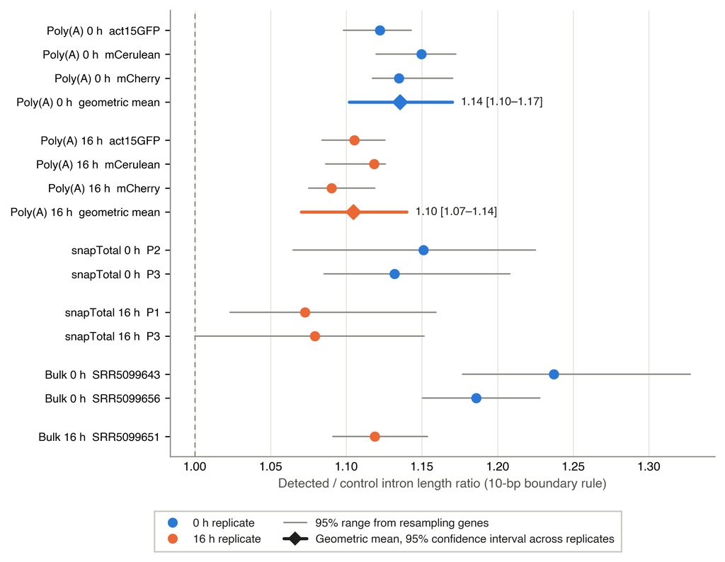

Detected/control intron length ratio in each plate, replicate or library, with ranges from resampling genes.

| Method | Hour | Preparation ratios | n | Geometric mean [95% confidence interval across replicates] | Gene-resampling range of the mean |
| --- | --- | --- | --- | --- | --- |
| Poly(A) | 0 | 1.122, 1.150, 1.135 | 3 | 1.136 [1.102–1.170] | 1.114–1.156 |
| Poly(A) | 16 | 1.105, 1.118, 1.090 | 3 | 1.105 [1.070–1.140] | 1.085–1.120 |
| snapTotal | 0 | 1.151, 1.132 | 2 | no interval under n≥3 reporting rule | 1.088–1.206 |
| snapTotal | 16 | 1.073, 1.079 | 2 | no interval under n≥3 reporting rule | 1.023–1.144 |
| Bulk | 0 | 1.237, 1.186 | 2 | no interval under n≥3 reporting rule | 1.173–1.262 |
| Bulk | 16 | 1.119 | 1 | no interval under n≥3 reporting rule | 1.091–1.154 |

Poly(A) summaries are geometric means, with 95% confidence intervals across the three replicates (t intervals on the log ratios, n = 3, two degrees of freedom). The replicates are separately developed strains, but they share one library at each hour and each reporter is tied to one strain. The intervals therefore describe the spread between three strains within a library, not three fully independent experiments. Ranges from resampling genes show how much the result depends on which genes are included, not variation between biological replicates. Values from different methods are different measurements, not replicates.

**The choice of controls affects the size of the result.** Controls must have no intronic reads at all. A long intron has more places for a read to land, so it is more likely to fail that condition. The control group can then be too short, which would exaggerate the difference. As a check, we allowed controls to have reads inside the intron, as long as no unit crosses a boundary with ≥5-bp anchors (last column). The ratios fall to 1.05–1.15 in snapTotal and bulk, with all intervals above 1, and to 1.06–1.12 in poly(A). The difference is smaller but in the same direction.

**Few cases are matched at full poly(A) depth.** At full depth almost every expressed intron has some evidence, so only 13% and 2% of cases find an unused control (1,059 and 241 pairs; ratios 1.12 and 1.17). These estimates describe a selected subset of cases, which is why the main poly(A) rows use snapTotal depth.

**Why we use boundary reads.** In snapTotal, counting only reads fully inside introns gave length ratios of 1.89 (0 h) and 2.35 (16 h). Adding boundary reads gave 1.25 and 1.18, and the boundary-only analysis above gives 1.14 and 1.08. A read can lie fully inside an intron only if the intron is longer than the read, so these reads preferentially find long introns. The much smaller boundary-only ratios suggest that this rule contributed substantially to the ratios of 1.89 and 2.35. A modest difference remains in all six comparisons. Other analysis rules also changed, so the comparison does not isolate the effect of the boundary requirement.

## 4. Gene span

Using the same matching at gene level, genes with intronic evidence are consistently **shorter** than matched controls in genomic span (start to end, including introns). Cases have at least two separate units with intronic sequence anywhere in the gene, possibly at the same intron and including reads inside introns, from at least 2 cells in single-cell data. Controls have none. A ratio of 0.80 means 20% shorter. Intron length and gene span use different cases, so their directions need not agree. The result is an association with detected intronic evidence. It does not measure how fast these genes are spliced.

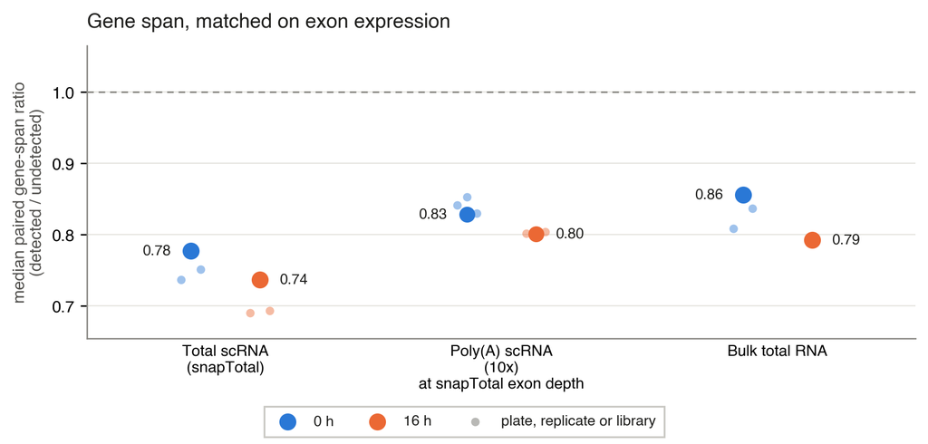

Median paired gene-span ratio (detected / undetected); light dots are plates, replicates or libraries. Bulk 16 h has one retained library. Dashed line: no difference.

At full poly(A) depth nearly every expressed gene has intronic signal, so only 4% and 1% of cases find a control (270 and 46 pairs), and the ratios (0.79 and 0.55) describe only a small matched minority.

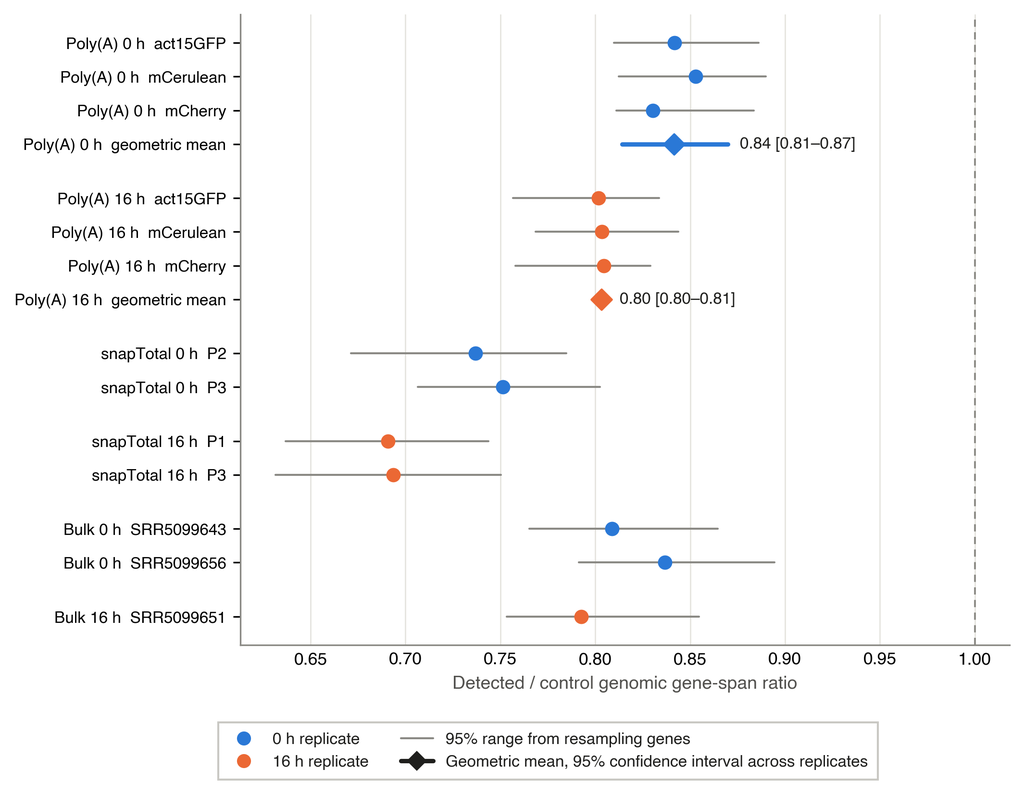

Detected/control gene span ratio in each plate, replicate or library, with ranges from resampling genes.

| Method | Hour | Preparation ratios | n | Geometric mean [95% confidence interval across replicates] | Gene-resampling range of the mean |
| --- | --- | --- | --- | --- | --- |
| Poly(A) | 0 | 0.842, 0.853, 0.830 | 3 | 0.842 [0.814–0.870] | 0.816–0.879 |
| Poly(A) | 16 | 0.802, 0.804, 0.804 | 3 | 0.803 [0.800–0.807] | 0.767–0.830 |
| snapTotal | 0 | 0.737, 0.751 | 2 | no interval under n≥3 reporting rule | 0.699–0.778 |
| snapTotal | 16 | 0.691, 0.694 | 2 | no interval under n≥3 reporting rule | 0.644–0.741 |
| Bulk | 0 | 0.809, 0.837 | 2 | no interval under n≥3 reporting rule | 0.790–0.866 |
| Bulk | 16 | 0.793 | 1 | no interval under n≥3 reporting rule | 0.753–0.855 |

**The poly(A) 16 h confidence interval is misleadingly narrow.** The three replicate values happen to be nearly identical: their log2 standard deviation is 0.002, compared with 0.024–0.030 at the other hours, and each replicate varies more than that between cell subsets. The interval should not be read as high precision. Ranges from resampling genes show more broadly how much the result depends on gene selection, but neither range covers shared library effects.

| Method | Hour | Detected cases | Matched pairs | Cases matched | Gene-span ratio |
| --- | --- | --- | --- | --- | --- |
| Total scRNA | 0 | 2,143 | 1,570 | 73% | 0.778 [0.73–0.82] |
| Total scRNA | 16 | 1,480 | 1,242 | 84% | 0.737 [0.69–0.78] |
| Poly(A) scRNA, snapTotal depth | 0 | 2,790–2,892 | 1,612–1,651 | 56%–59% | 0.828 (0.81–0.87) |
| Poly(A) scRNA, snapTotal depth | 16 | 2,886–2,974 | 1,533–1,570 | 52%–54% | 0.801 (0.78–0.82) |
| Bulk total RNA | 0 | 3,267 | 1,421 | 43% | 0.856 [0.79–0.89] |
| Bulk total RNA | 16 | 2,718 | 1,442 | 53% | 0.793 [0.75–0.85] |

Round brackets: lowest and highest of the five cell subsets, not a confidence interval. Square brackets: 95% range from resampling genes.

**What is behind the association with shorter genes?** The matching above accounts only for exon counts. We therefore modelled whether a gene has intronic evidence, using the same cases and controls and also accounting for intron number and total intron length. The association with shorter genes remains. The table gives the change in the odds of intronic evidence for each doubling of gene span; 1 means no association.

| Method | Hour | Own exon counts | Poly(A) counts instead | Own exon counts, adding last-exon length |
| --- | --- | --- | --- | --- |
| Poly(A) | 0 | 0.57 [0.53–0.61] | not possible | 0.71 [0.68–0.75] |
| Poly(A) | 16 | 0.58 [0.57–0.60] | not possible | 0.70 [0.67–0.72] |
| snapTotal | 0 | 0.42, 0.45 | 0.87, 0.87 | 0.47, 0.54 |
| snapTotal | 16 | 0.41, 0.39 | 0.92, 0.96 | 0.51, 0.44 |
| Bulk | 0 | 0.51, 0.53 | 1.02, 0.95 | 0.60, 0.60 |
| Bulk | 16 | 0.48 | 0.95 | 0.55 |

Poly(A): geometric mean of three replicates with 95% confidence interval, which does not cover shared library effects. snapTotal and bulk: one value for each plate or library.

**In snapTotal and bulk, the association seems to come mostly from how we count.** Introns are only 10%–12% of a typical gene's span, so gene span is mostly exon length. Among genes with similar poly(A) counts, doubling exon length multiplies exon counts by about 1.8–2.0 in these methods. A gene with long exons therefore seems to have fewer RNA molecules at the same exon count, and fewer chances to show an intronic read. When poly(A) counts measure expression instead, the association mostly disappears.

**This does not explain poly(A).** The same check cannot be applied to poly(A) itself. Using bulk exon counts divided by exon length as the measure of expression leaves the association in place (0.55 at 0 h and 0.59 at 16 h), although that measure largely tracks poly(A) counts. Poly(A) reads come mostly from near the 3′ end, so introns in short genes may be easier to reach. Accounting for the closest intron's distance from the 3′ end (last-exon length) weakens the association but does not remove it. The cause of the rest is unknown.

These checks use counts from both strands and are not adjusted for multiple comparisons. Poly(A) counts are only an approximate measure of RNA molecules, and they come from different libraries. These results are associations and do not measure how fast genes are spliced.

## 5. Checks on the poly(A) 16 h increase

The full-depth poly(A) intronic fraction rises from 0.67% at 0 h to 1.33% at 16 h (all cells). We checked for technical and compositional explanations:

[output not shown]

The increase remains in every check. Antisense RNA and unannotated transcripts could still contribute. Adjusted values here are sensitivity checks, and sections 2 and 8 keep the original counts.

**Detailed checks: cells, genes, priming, alignment and read coverage**

**Cells.** The whole 16 h poly(A) distribution shifts towards higher intronic fractions, so the increase is not confined to a few extreme cells. The median per-cell fraction rises from 0.67% to 1.32%, and removing the 5% of cells with the highest fractions leaves 0.66% and 1.30%. Per-cell fraction is only weakly related to exonic depth (Spearman ρ = -0.25 at 0 h, 0.06 at 16 h).

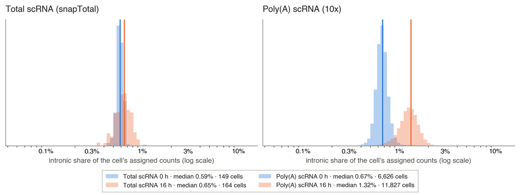

Per-cell intronic fraction, normalized density within each time point (log axis); vertical lines mark medians.

**Replicates.** Each replicate was subsampled five times to snapTotal's exon depth, and values are medians of the five subsets. All three show the increase in intronic fraction, from 0.66%–0.67% to 1.33%–1.35%, and the longer detected introns and shorter gene spans of sections 3–4.

| Replicate | Hour | Intronic fraction | Intron-length ratio | Gene-span ratio |
| --- | --- | --- | --- | --- |
| act15GFP | 0 | 0.664% | 1.12 | 0.84 |
| act15GFP | 16 | 1.348% | 1.11 | 0.80 |
| mCerulean | 0 | 0.674% | 1.15 | 0.85 |
| mCerulean | 16 | 1.327% | 1.12 | 0.80 |
| mCherry | 0 | 0.664% | 1.13 | 0.83 |
| mCherry | 16 | 1.342% | 1.09 | 0.80 |

**Genes.** The increase is not driven by a few highly expressed genes. Half of the intronic counts come from 29 genes at 0 h but 165 at 16 h, so the signal is broader at 16 h. Removing the largest contributors at either time (the same genes at both) still leaves a 2.3–2.8× increase:

| Top N removed | Genes removed | 0 h | 16 h | 16 h ÷ 0 h |
| --- | --- | --- | --- | --- |
| 10 | 18 | 0.46% | 1.09% | 2.38 |
| 25 | 42 | 0.39% | 1.03% | 2.65 |
| 50 | 89 | 0.35% | 0.96% | 2.75 |
| 100 | 171 | 0.33% | 0.87% | 2.68 |
| 200 | 323 | 0.31% | 0.79% | 2.56 |
| 500 | 768 | 0.28% | 0.64% | 2.30 |

Gene by gene, the median within-gene rise in poly(A) is 1.65–1.76× across minimum exon-count thresholds of 100–1,000, with 76%–81% of genes rising; snapTotal rises by a similar factor.

**Internal priming.** Oligo(dT) priming inside introns would place intronic UMI ends just upstream of A-rich sequence. We compared sense intronic ends with random positions in the same introns, for two A-richness definitions and three distances. **There is a priming signature at both times, but it is not consistently stronger at 16 h:** the observed-minus-random excess is 6–29 percentage points at 0 h and 6–22 at 16 h, larger at 16 h in 4 of 6 settings.

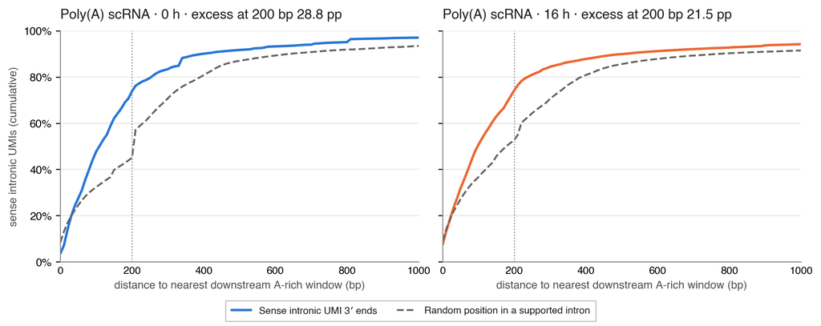

Cumulative distance from sense intronic UMI 3′ ends (solid) and random intronic positions (dashed) to the nearest downstream A-rich window (≥9 A in 10 bp); dotted line at 200 bp.

**Alignment.** Misalignment of spliced reads into introns is rare: in reads simulated from 420 real introns, 0.14% of spliced reads were called intronic (1.7% with 1% sequencing errors), and none had 10-bp boundary support. **The increase remains when we rebuild the counts with progressively stricter filters (tiers)**, and requiring 10-bp boundary support strengthens it.

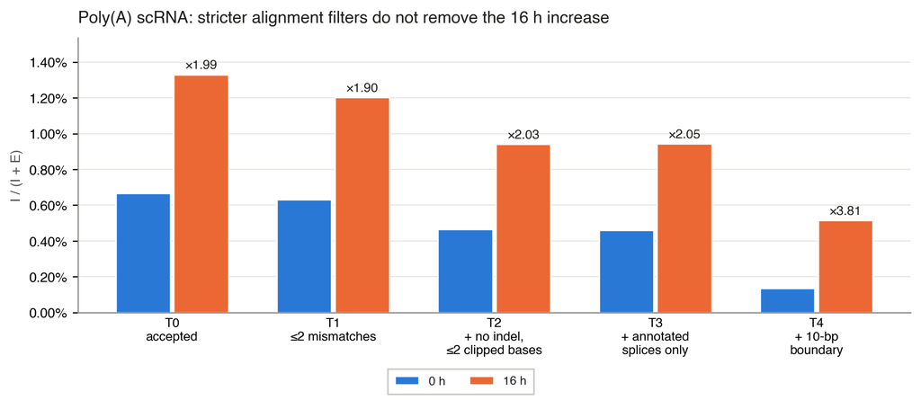

Poly(A) intronic fraction at 0 h and 16 h under cumulative alignment filters T0–T4 (see table).

| Tier | Cumulative requirement | Fraction, 0 h | Fraction, 16 h | 16 h ÷ 0 h |
| --- | --- | --- | --- | --- |
| T0 | accepted by the shared counting | 0.668% | 1.330% | 1.99 |
| T1 | at most 2 mismatches | 0.632% | 1.204% | 1.90 |
| T2 | + no indel, at most 2 soft-clipped bases | 0.464% | 0.940% | 2.03 |
| T3 | + every splice annotated, overhangs ≥10 bp | 0.460% | 0.943% | 2.05 |
| T4 | + intronic units need a 10-bp boundary | 0.135% | 0.516% | 3.81 |

**Reads per UMI.** 16 h has more reads per exon-only UMI (1.91 vs 1.64), which could make intronic parts of molecules easier to catch. But the increase holds among single-read UMIs (0.68% to 1.38%), and reweighting 16 h to the 0 h read-support distribution gives 1.34%. Near-duplicate intronic UMIs (one base apart, same cell and gene) are rare (0.1% and 0.4%).

**Read-coverage examples.** Two well-covered genes with rising intronic fractions: DDB_G0272190 shows intronic coverage across the gene; DDB_G0291255 shows soft-clipped reads piling up near one exon, possibly an unannotated transcript start. In multi-intron genes the first intron's share of intronic units rises from 19% to 27%. Black outline: all aligned reads. Colour: the subset of those reads that overlap an intron, so colour inside an exon is the exonic part of such reads. These tracks show read coverage, not UMI counts.

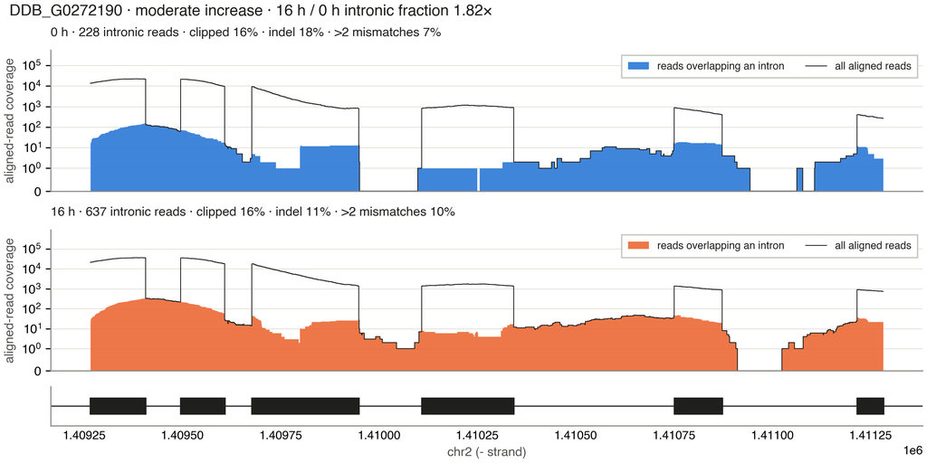

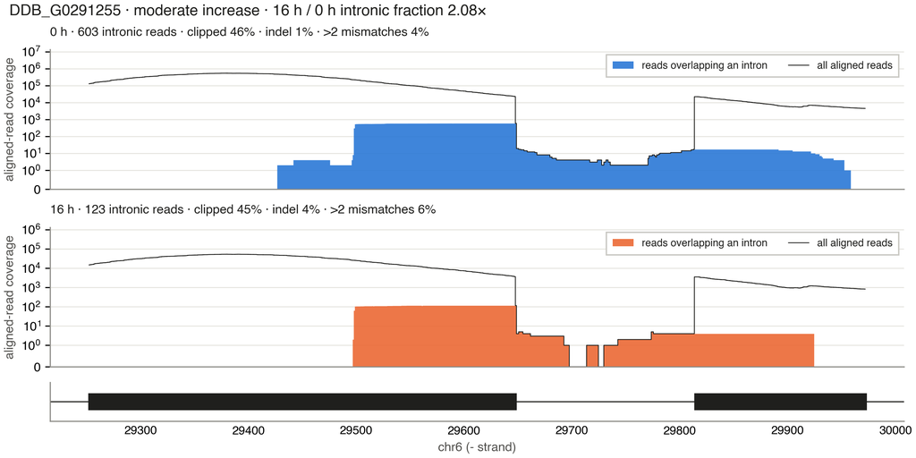

### A+T rich introns and bulk antisense check

**Recovery of simulated reads from A+T rich sequence.** We simulated 1,231,594 reads from the genome sequence, at 75 and 151 bases, with 0 or 1% expected substitutions. Reads that were unmapped, not unique or rejected by our filters stay in the denominator. For 75-base reads inside introns with 95–100% read A+T, the loss of counts from the source intron is 5.17% without added errors and 7.05% at 1% expected substitutions. These simulated rates are not measured loss rates in the real libraries.

After standardizing for read type and intron length, recovery is 99.116% for introns with ≥90% A+T and 98.831% for introns below 90% A+T. Recovery of qualifying boundary reads with ≥10 bases is 99.327% and 98.663%. High A+T introns show no general loss of recovery in this simulation, but the simulation does not show that detection is unbiased in the real data. The 500 gene resamples show how much the result depends on gene selection, not uncertainty between biological replicates. The simulation does not cover library preparation losses, real error and coverage distributions, or rescue by other reads in the same unit. It also finds false intronic calls and some qualifying boundary evidence in spliced reads with added errors, so the zero boundary false positives in the earlier small simulation do not guarantee error-free case selection.

**A+T rich introns in the real libraries.** Among introns of genes with ≥20 exon-only units, after standardizing for intron length and gene expression, introns with ≥90% A+T reach the case threshold 7.7–11.6 percentage points less often than other introns, in all three methods at both times. The simulation finds no matching alignment loss, but it does not test every source of library or sequencing bias, and this analysis cannot identify the cause. Intron length and A+T content are essentially uncorrelated (Spearman 0.03), which argues against a simple A+T explanation of the length association but does not exclude selection effects. The association also differs with A+T content: 1.15–1.29 in the least A+T rich quarter of introns and 0.98–1.06 in the most A+T rich quarter (exploratory estimates). Sequence composition therefore needs to be considered when interpreting the association.

**Bulk antisense check.** We recounted all three full libraries, and every original gene and intron count and quality control counter was reproduced. All 775 retained Rosengarten loci can compete for reads, and both annotations are compared on the same 7,689 coding genes. In these libraries, read 1 is on the sense strand, which is supported by 99.1%–99.5% of unambiguous exon read 1 alignments. We counted both conventions. Strand filtering happens before gene assignment, so it can rescue units that were ambiguous when counted from both strands.

| Bulk counting condition, same 7,689 genes | 0 h | 16 h | 16−0 h, percentage points |
| --- | --- | --- | --- |
| Original counts, excluding the 96 overlapping genes | 0.747% | 0.877% | +0.130 |
| Added loci, both strands | 0.746% | 0.876% | +0.130 |
| Added loci, sense reads | 0.725% | 0.772% | +0.047 |

The pooled increase is smaller with sense reads. The 16 h value with sense reads lies between the two 0 h library values, so the results do not establish a replicated developmental increase. Detected introns remain longer and genes shorter in each library, and both matching checks pass. The check uses fixed alignments and does not prove that all antisense RNA was removed.

**Poly(A) sense-read recount.** We recounted all reads at all six hours. A parallel count from both strands reproduced every saved gene, intron and U/S count in all 36 chromosome and time point combinations, including 4–20 h. 96.3%–98.9% of exon-only units lie on the sense strand, which supports the strand assignment at every hour. Adding the antisense and lncRNA loci alone changes almost nothing (0.661% to 1.328%). When we use only sense reads, each unit is rebuilt from those reads. Opposite-strand units are 7.1% of intronic units at 0 h and 19.0% at 16 h.

| Poly(A) counting condition, same 7,689 genes | 0 h | 16 h | Paired 16−0 h, three replicates, points [adjusted 95% confidence interval] | U/S fold 0→16 h [95% confidence interval] |
| --- | --- | --- | --- | --- |
| Original counts, excluding the 96 overlapping genes | 0.661% | 1.328% | +0.67 [0.55–0.80] | 2.91 [2.66–3.18] |
| Sense reads only, added loci competing | 0.623% | 1.120% | +0.50 [0.33–0.67] | 2.57 [2.42–2.72] |

Adjusted intervals are wider because they account for making several comparisons. About a quarter of the 0–16 h increase in the intronic fraction was opposite-strand signal, but the increase remains in all three replicates. The 20−0 h change is +0.39 points [0.12–0.65]. Detected introns are longer and genes shorter in all 18 reporter and hour estimates with sense reads. Opposite-strand reads can be true antisense RNA or library artefacts, and we cannot separate the two here. We did not refit velocity with sense reads only. Intervals use n = 3 and do not cover shared library effects.

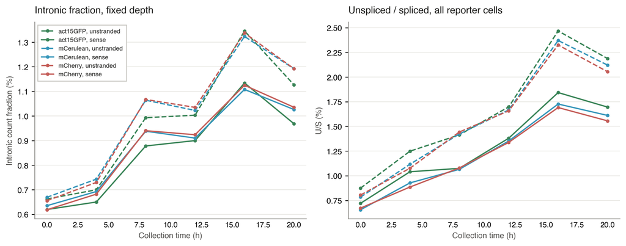

Dashed: both strands. Solid: sense reads only. Same cells within each fraction curve; 7,689 genes.

**Bulk time course, sense reads.** All 23 libraries reproduced their saved counts and were recounted with sense reads. U/S is lowest at 0 h and highest at 24 h in both replicates, rising 2.9- and 2.3-fold by 24 h. The intronic fraction is less clear: +0.16 percentage points from 0 to 16 h in replicate 1 (replicate 2 has no 16 h library), -0.13 by 20 h in replicate 2, and higher in both by 24 h. With two replicates, bulk remains descriptive.

## 6. Splicing time, intron position and RNA velocity

At each eligible intron (one that passed the section 3 rules), a second counting run counts **unspliced (U)** units, which cross an exon–intron boundary with 10-bp anchors, and **spliced (S)** units, which are spliced exactly across the annotated intron. **U/S rises from 0 h to 16 h in all three methods, and across development in bulk:** measured every 2 h, bulk U/S is lowest at 0 h (1.70%), lies between 2.6% and 4.2% from 2 to 22 h, climbing after 8 h, and is highest at 24 h (5.18%). Poly(A) U/S uses all cells, not the depth-matched subsets. These values use reads from both strands. Section 5 shows that the rise remains with sense reads only, and the replicate statistics below follow the same pattern.

**How long introns persist (scenarios, not measurements).** At steady state, U/S ≈ intron persistence time ÷ mRNA lifetime. mRNA half-lives in *Dictyostelium* vary. In vegetative cells, mRNA decays in at least two main groups, with half-lives of about 50 minutes and about 10 hours ([Casey et al. 1983](https://pubmed.ncbi.nlm.nih.gov/6825928/)). In developing cells disaggregated with cAMP, the mRNA population has an apparent half-life of about 4 hours ([Manrow and Jacobson 1988](https://pubmed.ncbi.nlm.nih.gov/2847029/)). No single lifetime applies, and a 4 h half-life doubles any scenario below. Changes in mRNA stability could also change U/S without any change in splicing. With a 2 h mRNA half-life, the model gives about **1–9 minutes** in the total-RNA methods (snapTotal at 0 and 16 h, bulk at all time points), and 0.3–43 minutes across all methods and the published 0.9–9.6 h half-life range. These numbers come from the model's assumptions (steady state, equal capture of U and S, unmeasured half-lives). They are not measured splicing times.

**Model and counting details**

Per-molecule logic: if introns last 1 minute and spliced mRNA about 100 minutes, we expect about 1 unspliced copy per 100 spliced. So persistence ≈ U/S × mean spliced-mRNA lifetime (half-life / ln 2). An unspliced molecule has two boundaries where U can be counted and a spliced one only one junction, so the range includes the result halved (factor 0.5–1). Half-lives are from [Shapiro et al. 1988](https://pubmed.ncbi.nlm.nih.gov/2898728/) (selected mRNAs in amoebae), not our cells at 0 and 16 h. Developing cells need not be at steady state, and poly(A) capture can under-sample unspliced RNA. Each intron is assessed separately. U: an uninterrupted alignment across an exon–intron boundary with ≥10 bases on each side, and no splice gap overlapping the intron. S: a splice alignment joining the intron's exact annotated boundaries with ≥10 aligned bases on each side, and no aligned sequence inside the intron. A unit with incompatible evidence at an intron counts as neither there, but can count at another intron, so summed U and S are not numbers of molecules. The second counting run also recounts the section 2 gene-level counts, and they match exactly at 0 h and 16 h. Counts are pooled across cells.

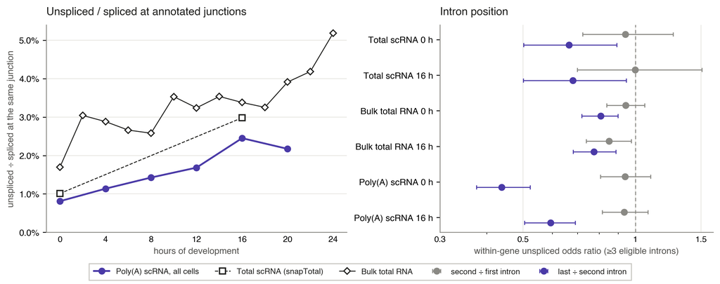

Left: unspliced ÷ spliced units at the same annotated junctions (poly(A) every 4 h, bulk every 2 h, snapTotal at 0 and 16 h). Right: within-gene odds ratios by intron position with 95% gene-resampling intervals; dashed line: no difference.

| Method | Hour | U | S | U/S | Scenario minutes (2 h half-life) | Scenario minutes (0.9–9.6 h half-lives) |
| --- | --- | --- | --- | --- | --- | --- |
| Total scRNA | 0 | 10,910 | 1,079,004 | 1.01% | 0.9–1.8 | 0.4–8 |
| Total scRNA | 16 | 7,436 | 249,541 | 2.98% | 2.6–5.2 | 1.2–25 |
| Poly(A) scRNA | 0 | 219,395 | 27,082,177 | 0.81% | 0.7–1.4 | 0.3–7 |
| Poly(A) scRNA | 4 | 190,273 | 16,754,167 | 1.14% | 1.0–2.0 | 0.4–9 |
| Poly(A) scRNA | 8 | 319,435 | 22,414,699 | 1.43% | 1.2–2.5 | 0.6–12 |
| Poly(A) scRNA | 12 | 265,656 | 15,778,149 | 1.68% | 1.5–2.9 | 0.7–14 |
| Poly(A) scRNA | 16 | 712,839 | 29,091,896 | 2.45% | 2.1–4.2 | 1.0–20 |
| Poly(A) scRNA | 20 | 361,237 | 16,636,281 | 2.17% | 1.9–3.8 | 0.8–18 |
| Bulk total RNA | 0 | 16,624 | 978,748 | 1.70% | 1.5–2.9 | 0.7–14 |
| Bulk total RNA | 2 | 22,341 | 734,446 | 3.04% | 2.6–5.3 | 1.2–25 |
| Bulk total RNA | 4 | 17,655 | 612,780 | 2.88% | 2.5–5.0 | 1.1–24 |
| Bulk total RNA | 6 | 20,766 | 780,621 | 2.66% | 2.3–4.6 | 1.0–22 |
| Bulk total RNA | 8 | 19,159 | 742,724 | 2.58% | 2.2–4.5 | 1.0–21 |
| Bulk total RNA | 10 | 24,215 | 685,695 | 3.53% | 3.1–6.1 | 1.4–29 |
| Bulk total RNA | 12 | 13,217 | 408,075 | 3.24% | 2.8–5.6 | 1.3–27 |
| Bulk total RNA | 14 | 21,391 | 604,946 | 3.54% | 3.1–6.1 | 1.4–29 |
| Bulk total RNA | 16 | 14,517 | 429,635 | 3.38% | 2.9–5.8 | 1.3–28 |
| Bulk total RNA | 18 | 33,432 | 1,027,979 | 3.25% | 2.8–5.6 | 1.3–27 |
| Bulk total RNA | 20 | 31,313 | 800,798 | 3.91% | 3.4–6.8 | 1.5–32 |
| Bulk total RNA | 22 | 18,561 | 443,568 | 4.18% | 3.6–7.2 | 1.6–35 |
| Bulk total RNA | 24 | 35,812 | 691,020 | 5.18% | 4.5–9.0 | 2.0–43 |

**Intron position.** In genes with ≥3 eligible introns, we compared U/S between introns (length-adjusted odds ratio; below 1 means lower U/S at the later intron):

- second vs first: 0.85–1.00, no consistent difference (only the bulk 16 h interval excludes 1);
- last vs second: 0.66–0.81 in snapTotal and bulk, and 0.44–0.59 in poly(A).

The last eligible intron has lower U/S than the second, which is consistent with faster splicing near the 3′ end. U and S are different types of reads, so the ratio cancels detection only if their relative detection is the same at both positions, and we have not tested this.

**Intron-position method**

Each compared intron needs ≥20 U + S units. Differences in log((U + 0.5)/(S + 0.5)) are regressed on log2 length ratios; the exponentiated intercept is the reported ratio. Each gene contributes one intron pair per comparison; intervals are 2.5–97.5% over 1,000 resamples of genes (shown in the figure). First, second and last refer to eligible introns after filtering; 0–2.1% of supported last/second pairs per replicate use a last eligible intron that is not the true terminal intron.

**Replicate evidence.** In the three poly(A) replicates, U/S rises 2.97-fold from 0 to 16 h [95% confidence interval across paired replicates 2.71–3.26]. Last / second is below 1 in all 13 samples across the three methods; second / first and last / first are less consistent. snapTotal and bulk are shown individually. Intervals use n = 3 and do not cover shared library effects or differences between the reporter strains.

| Hour | Comparison | Geometric mean of three poly(A) replicates | 95% confidence interval | 95% confidence interval, adjusted for three comparisons |
| --- | --- | --- | --- | --- |
| 0 | second / first | 0.839 | 0.753–0.935 | 0.692–1.017 |
| 0 | last / second | 0.378 | 0.318–0.450 | 0.278–0.516 |
| 0 | last / first | 0.339 | 0.319–0.361 | 0.304–0.379 |
| 16 | second / first | 0.852 | 0.701–1.036 | 0.602–1.207 |
| 16 | last / second | 0.521 | 0.396–0.686 | 0.320–0.849 |
| 16 | last / first | 0.469 | 0.308–0.713 | 0.223–0.987 |

With sense reads, on the 7,689 genes left after the antisense exclusion, the poly(A) last / second ratio is 0.33 at 0 h (95% confidence interval adjusted for three comparisons 0.26–0.42) and 0.44 at 16 h (0.40–0.49).

**U/S across development.** Using the same three replicates at every hour, sense-only U/S is higher than at 0 h at each later time and lower at 20 h than at 16 h:

| Poly(A) U/S, sense reads | Fold change | 95% confidence interval, adjusted across six comparisons |
| --- | --- | --- |
| 0 → 4 h | 1.39 | 1.03–1.88 |
| 0 → 8 h | 1.57 | 1.18–2.10 |
| 0 → 12 h | 1.99 | 1.58–2.51 |
| 0 → 16 h | 2.57 | 2.22–2.98 |
| 0 → 20 h | 2.37 | 1.95–2.89 |
| 16 → 20 h | 0.92 | 0.88–0.97 |

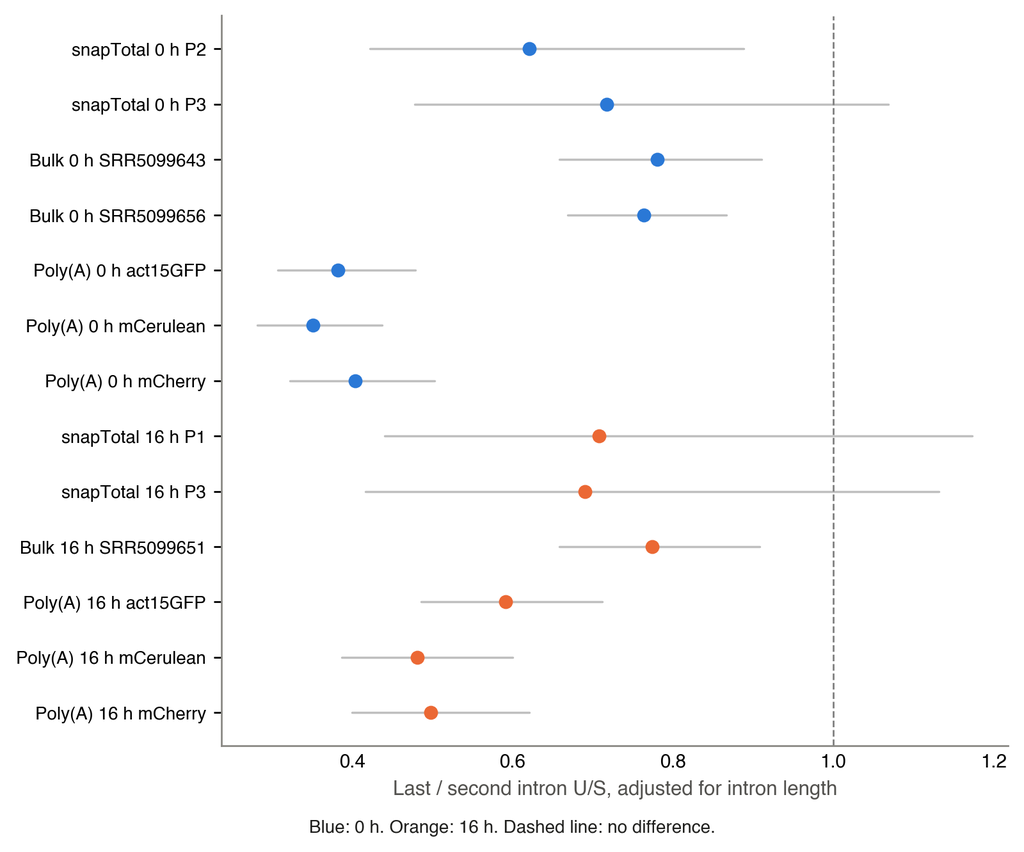

U/S at the last intron relative to the second, adjusted for intron length, in each sample. Below 1 means lower U/S at the last intron. Lines: 95% ranges from resampling genes, adjusted for three comparisons. They do not show uncertainty between replicates.

**RNA velocity.** We tested whether velocity transitions (scVelo, stochastic model; exon-only units as spliced, intronic units as unspliced) point towards later-collected cells. Each replicate was fitted separately and compared with 100 refits in which its intronic counts were shuffled:

| Replicate | Cells pointing later (4–16 h) | Own shuffled mean | Excess (points) | p adjusted for three replicates |
| --- | --- | --- | --- | --- |
| act15GFP | 44.6% | 37.3% | +7.3 | 0.030 |
| mCerulean | 41.1% | 37.2% | +4.0 | 0.030 |
| mCherry | 36.5% | 35.5% | +1.0 | 0.129 |

Two of the three replicates exceed their own shuffled control. The mean excess is **4.1 percentage points [95% confidence interval across replicates -3.8 to +12.0]**, n = 3. The interval includes zero, which suggests that the evidence is modest and varies between replicates. The shuffle p value tests only whether the fit beats shuffled data. It is not a confidence level that the trajectories are correct.

**Velocity details**

666 atlas cells per replicate at each of six time points. The 0 h and 20 h endpoints are excluded because they can only point one way. With 100 shuffles the smallest possible unadjusted p-value is 1/101. The shuffles also change gene selection and gene correlations. The earlier joint fit of all three replicates (36.4%, p = 0.010) is replaced by these results. It is a different method, so these intervals do not apply to it. Shared library effects and differences between the reporter strains are not covered by the between-replicate interval.

## 7. Developmental time courses

Both time courses are counted with the section 1 rules at every time point: poly(A) every 4 h, subsampled to one fixed exon depth (snapTotal's 16 h total), and bulk every 2 h from all 23 libraries.

**Intronic fraction is higher later in development in poly(A), less clearly in bulk.** Poly(A) goes from 0.66% at 0 h to about 1.0% at 8–12 h, 1.34% at 16 h and 1.15% at 20 h; the drop from 16 to 20 h is not confirmed. Bulk is lowest at 0 h (0.75%), between 0.80% and 0.99% from 2 to 22 h without a steady trend, and highest at 24 h (1.16%).

**Detected introns are modestly longer than controls at every time point**: 1.08–1.11× in poly(A) from 4 h onwards (1.22× at 0 h) and 1.11–1.17× in bulk, without a clear monotonic pattern.

**Genes with intronic evidence are shorter than matched controls at every time point**, with descriptive ratios of 0.80–0.86× in poly(A) and 0.69–0.86× in bulk. No change in either length association over time remains after adjustment with counts from both strands. With sense reads the intron-length ratio is slightly lower at 16 h than at 0 h (section 5 data). These associations do not establish a causal effect of gene length on splicing.

**Replicate statistics (three paired poly(A) replicates, one fixed exon depth).**

| Comparison | Mean change, percentage points | 95% confidence interval, adjusted across nine temporal comparisons |
| --- | --- | --- |
| 16−0 h | +0.670 | +0.549 to +0.791 |
| 20−0 h | +0.503 | +0.216 to +0.790 |
| 20−16 h | -0.167 | -0.505 to +0.170 |

After adjusting 12 within-time comparisons, five of six hours exclude no difference for each length association. With counts from both strands, the exceptions are intron length at 16 h and gene span at 0 h. With sense reads, they are intron length at 20 h and gene span at 4 h. These intervals are wider than in sections 3 and 4 because they cover more comparisons, and the 0 h depth target differs. We did not run a monotonic or global trend test. Bulk has two replicates and is descriptive.

All poly(A) replicates at one hour share a library, so changes over time cannot be separated from library differences, and the intervals do not cover those differences.

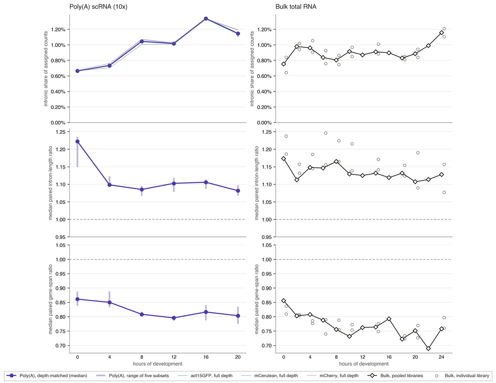

Top: intronic share I / (I + E). Middle: boundary-only paired intron-length ratio (section 3). Bottom: paired gene-span ratio (section 4); bulk matches only 36%–57% of cases. Dashed lines: no difference. Left: poly(A) depth-matched median with the range of five subsets; thin lines are the replicates at full depth. Right: bulk, with connected diamonds recalculated after adding together the counts from the libraries at each time point, and individual libraries as open circles. Adding the counts changes which introns or genes qualify and how they match, so a diamond can fall outside the range of the circles. Median means the median of the matched pair ratios within each analysis, not across libraries.

Between-library variation in bulk is comparable to the changes over time: libraries from the same time point differ by up to 0.20 percentage points in intronic fraction, 0.10 in intron-length ratio and 0.05 in gene-span ratio.

**Time-course details and bulk libraries**

Poly(A) subsets hold 157–443 cells (across all five draws per hour). At 16 h the target equals section 2's, so values agree with section 2 up to random draws; at 0 h the depth is lower than in section 3 (which matched snapTotal's larger 0 h total), and the length ratio is higher at this depth (1.22 vs 1.14). Replicate 2 at 12, 16 and 22 h was excluded in the original bulk publication, so those time points have one library and the others have two. The earlier bulk time course used a separate counting pipeline and is replaced by these results.

| Hour | Library | Intronic fraction | Intron-length ratio | Gene-span ratio |
| --- | --- | --- | --- | --- |
| 0 | SRR5099643 | 0.642% | 1.24 | 0.81 |
| 0 | SRR5099656 | 0.838% | 1.19 | 0.84 |
| 2 | SRR5099644 | 1.019% | 1.13 | 0.80 |
| 2 | SRR5099657 | 0.939% | 1.16 | 0.81 |
| 4 | SRR5099645 | 1.053% | 1.14 | 0.79 |
| 4 | SRR5099658 | 0.904% | 1.18 | 0.78 |
| 6 | SRR5099646 | 0.926% | 1.16 | 0.74 |
| 6 | SRR5099659 | 0.757% | 1.25 | 0.79 |
| 8 | SRR5099647 | 0.745% | 1.16 | 0.75 |
| 8 | SRR5099660 | 0.861% | 1.22 | 0.79 |
| 10 | SRR5099648 | 0.967% | 1.14 | 0.77 |
| 10 | SRR5099661 | 0.849% | 1.22 | 0.75 |
| 12 | SRR5099649 | 0.870% | 1.12 | 0.76 |
| 14 | SRR5099650 | 1.007% | 1.17 | 0.78 |
| 14 | SRR5099662 | 0.883% | 1.14 | 0.75 |
| 16 | SRR5099651 | 0.896% | 1.12 | 0.79 |
| 18 | SRR5099652 | 0.808% | 1.12 | 0.72 |
| 18 | SRR5099663 | 0.850% | 1.15 | 0.73 |
| 20 | SRR5099653 | 0.942% | 1.09 | 0.77 |
| 20 | SRR5099664 | 0.837% | 1.19 | 0.73 |
| 22 | SRR5099654 | 0.989% | 1.11 | 0.69 |
| 24 | SRR5099655 | 1.103% | 1.08 | 0.76 |
| 24 | SRR5099665 | 1.207% | 1.16 | 0.80 |

## 8. Key results at 0 h and 16 h

Poly(A) values are the median and range of the depth-matched subsets. Square brackets are 95% ranges from resampling genes.

| Measurement | Total scRNA (snapTotal) 0 h | Total scRNA (snapTotal) 16 h | Poly(A) scRNA, snapTotal depth 0 h | Poly(A) scRNA, snapTotal depth 16 h | Bulk total RNA 0 h | Bulk total RNA 16 h |
| --- | --- | --- | --- | --- | --- | --- |
| Intronic share of assigned counts | 0.593% | 0.676% | 0.667% (0.664%–0.671%) | 1.327% (1.294%–1.333%) | 0.752% | 0.896% |
| Expressed genes with intronic signal | 49.2% | 39.6% | 59.2% (58.7%–59.3%) | 59.9% (59.6%–60.4%) | 64.0% | 58.1% |
| Paired gene-span ratio | 0.78 [0.73–0.82] | 0.74 [0.69–0.78] | 0.83 (0.81–0.87) | 0.80 (0.78–0.82) | 0.86 [0.79–0.89] | 0.79 [0.75–0.85] |
| cases matched | 73% | 84% | 57% (56%–59%) | 53% (52%–54%) | 43% | 53% |
| Paired boundary-only intron-length ratio | 1.14 [1.08–1.18] | 1.08 [1.02–1.11] | 1.14 (1.12–1.15) | 1.09 (1.09–1.12) | 1.17 [1.14–1.20] | 1.12 [1.09–1.15] |
| cases matched | 97% | 99% | 84% (83%–85%) | 82% (81%–82%) | 89% | 91% |
| Unspliced ÷ spliced at the same junction | 1.01% | 2.98% | 0.81%† | 2.45%† | 1.70% | 3.38% |

† Poly(A) U/S uses all cells, because U/S was not calculated for the depth-matched subsets.

Across the three methods, intronic evidence is 0.6%–1.3% of counts. The poly(A) increase from 0 h to 16 h remains with sense reads only, at about three-quarters of its size. U/S also rises in bulk, but the bulk intronic fraction increase is less convincing with sense reads, and snapTotal cannot be tested by strand. Detected introns are modestly longer than matched controls, less so in the most A+T rich introns, and genes with intronic evidence are shorter. The persistence times are model scenarios, not measured splicing speeds.